# Pertemuan 2 - Regresi

Yogi Nur Hamid

## Pemanggilan *Packages*

```r
library(dplyr)
library(TTR)
library(forecast)
library(lmtest) #digunakan untuk uji formal pendeteksian autokorelasi
```

```r
library(orcutt) #untuk membuat model regresi Cochrane-Orcutt
library(HoRM) #untuk membuat model regresi Hildreth-Lu
library(corrplot)
```

## Input Data

```r
data <- read.csv("C:/Users/ASUS/OneDrive/Documents/sem 5/Metode Peramalan Deret Waktu/BAJFINANCE.csv")
data
```

| date | close | high | low | open | volume | sma5 | sma10 | sma15 | sma20 | ema5 | ema10 | ema15 | ema20 | upperband | middleband | lowerband | HT_TRENDLINE | KAMA10 | KAMA20 | KAMA30 | SAR | TRIMA5 | TRIMA10 | TRIMA20 | ADX5 | ADX10 | ADX20 | APO | CCI5 | … |
| --- | --- | --- | --- | --- | --- | --- | --- | --- | --- | --- | --- | --- | --- | --- | --- | --- | --- | --- | --- | --- | --- | --- | --- | --- | --- | --- | --- | --- | --- | --- |
| 4/7/2015 | 434.12 | 436.50 | 421.03 | 427.50 | 184490 | 416.608 | 406.580 | 405.3407 | 407.8915 | 419.5083 | 412.8633 | 411.0694 | 410.3932 | 439.9211 | 416.608 | 393.2949 | 411.0805 | 411.3815 | 411.8166 | 416.3879 | 339.22 | 416.2222 | 403.6150 | 403.2926 | 60.148568 | 29.50201 | 23.727598 | -6.12115385 | 113.7237504 | … |
| 4/8/2015 | 448.92 | 453.00 | 428.56 | 434.12 | 188240 | 426.398 | 411.542 | 408.5680 | 409.2630 | 429.3122 | 419.4191 | 415.8007 | 414.0624 | 454.2174 | 426.398 | 398.5786 | 411.9537 | 423.7739 | 414.0722 | 417.4711 | 339.22 | 425.3667 | 408.5893 | 403.5053 | 65.865024 | 32.86250 | 24.686480 | -3.84916667 | 123.6934667 | … |
| 4/9/2015 | 450.47 | 469.90 | 440.01 | 454.20 | 535180 | 434.322 | 416.908 | 411.7067 | 410.8740 | 436.3648 | 425.0647 | 420.1343 | 417.5298 | 462.4811 | 434.322 | 406.1629 | 413.0795 | 434.2050 | 416.9751 | 418.8058 | 339.22 | 434.7622 | 414.8620 | 404.4075 | 71.184666 | 36.70127 | 25.969248 | -1.34339744 | 109.1141738 | … |
| 4/10/2015 | 452.21 | 459.80 | 447.88 | 453.00 | 324510 | 441.962 | 422.647 | 414.8667 | 412.8210 | 441.6465 | 430.0002 | 424.1438 | 420.8327 | 463.9934 | 441.962 | 419.9306 | 414.3102 | 442.2072 | 420.9957 | 420.5360 | 339.22 | 443.5822 | 421.9400 | 406.0263 | 75.440380 | 40.15616 | 27.187878 | 2.48615385 | 74.4317559 | … |
| 4/13/2015 | 445.38 | 452.21 | 442.00 | 452.21 | 300820 | 446.220 | 427.619 | 417.6553 | 414.3925 | 442.8910 | 432.7965 | 426.7983 | 423.1705 | 459.1304 | 446.220 | 433.3096 | 415.8302 | 443.1218 | 422.7778 | 421.6601 | 339.22 | 448.1300 | 429.0880 | 408.2648 | 72.971659 | 41.78253 | 27.986163 | 6.05711539 | 10.5001382 | … |
| 4/15/2015 | 445.60 | 448.98 | 437.70 | 445.50 | 383270 | 448.516 | 432.562 | 420.5587 | 416.1345 | 443.7940 | 435.1244 | 429.1485 | 425.3067 | 453.8799 | 448.516 | 443.1521 | 417.2087 | 443.8345 | 424.8358 | 422.7030 | 339.22 | 449.2056 | 435.6710 | 411.1190 | 67.003910 | 42.21796 | 28.490444 | 9.73878205 | -65.3598958 | … |
| 4/16/2015 | 458.50 | 460.50 | 437.50 | 447.23 | 104480 | 450.432 | 438.415 | 424.5053 | 419.0340 | 448.6960 | 439.3745 | 432.8175 | 428.4679 | 460.1119 | 450.432 | 440.7521 | 418.3052 | 448.3149 | 431.5201 | 424.8053 | 339.22 | 448.9700 | 441.3083 | 414.6379 | 65.536385 | 43.49139 | 29.251283 | 14.04044872 | 40.9144735 | … |
| 4/17/2015 | 452.95 | 460.51 | 444.13 | 458.00 | 187220 | 450.928 | 442.625 | 428.2480 | 421.5120 | 450.1140 | 441.8428 | 435.3340 | 430.7996 | 460.8168 | 450.928 | 441.0392 | 419.1778 | 449.2273 | 434.6306 | 425.2961 | 339.22 | 449.9689 | 445.3967 | 418.5445 | 64.364909 | 44.63819 | 29.974314 | 17.56211538 | 53.0159929 | … |
| 4/20/2015 | 455.83 | 459.40 | 443.87 | 447.29 | 190990 | 451.652 | 446.807 | 432.3153 | 424.0630 | 452.0193 | 444.3859 | 437.8960 | 433.1834 | 462.3103 | 451.652 | 440.9937 | 419.7749 | 450.5216 | 437.7784 | 426.1071 | 339.22 | 452.6456 | 448.2850 | 422.7634 | 63.103721 | 45.59998 | 30.644880 | 20.77173077 | 64.2858964 | … |
| 4/21/2015 | 437.34 | 455.00 | 413.93 | 450.50 | 1257380 | 450.044 | 448.132 | 435.0940 | 425.7525 | 447.1262 | 443.1049 | 437.8265 | 433.5793 | 465.3950 | 450.044 | 434.6930 | 420.3608 | 450.1365 | 437.7521 | 426.1936 | 339.22 | 452.2722 | 449.6320 | 427.0191 | 57.634608 | 41.28152 | 29.734732 | 22.05346154 | -130.3038183 | … |

[output cut: 1849 more lines]

```r
str(data)
```

```
## 'data.frame':    1859 obs. of  60 variables:
##  $ date        : chr  "4/7/2015" "4/8/2015" "4/9/2015" "4/10/2015" ...
##  $ close       : num  434 449 450 452 445 ...
##  $ high        : num  436 453 470 460 452 ...
##  $ low         : num  421 429 440 448 442 ...
##  $ open        : num  428 434 454 453 452 ...
##  $ volume      : int  184490 188240 535180 324510 300820 383270 104480 187220 190990 1257380 ...
##  $ sma5        : num  417 426 434 442 446 ...
##  $ sma10       : num  407 412 417 423 428 ...
##  $ sma15       : num  405 409 412 415 418 ...
##  $ sma20       : num  408 409 411 413 414 ...
##  $ ema5        : num  420 429 436 442 443 ...
##  $ ema10       : num  413 419 425 430 433 ...
##  $ ema15       : num  411 416 420 424 427 ...
##  $ ema20       : num  410 414 418 421 423 ...
```

[output cut: 46 more lines]

#Mengubah format Tanggal

```r
date <- as.Date(data$date, format="%m/%d/%Y")
date <- substr(date, 1,4)
date
```

[output not shown]

[output cut: 171 more lines]

#Membuat dataframe yang diperlukan

Data yang digunakan dalam kesempatan kali ini adalah data Bajaj Finance Periode 2021.

```r
#Peubah yang digunakan
volume <- data$volume #sebagai Y
high <- data$high #Sebagai X1
low <- data$low #Sebagai X2
atr <- data$ATR #Sebagai X3
trange <- data$Trange #Sebagai X4

#Menggabungkan data
datagab <- cbind.data.frame(date,volume,high,low,atr,trange)

#Ambil data periode 2021 saja
datagab <- datagab[date == "2021",]
datagab
```

|  | date | volume | high | low | atr | trange |
| --- | --- | --- | --- | --- | --- | --- |
| 1412 | 2021 | 1447187 | 5338.00 | 5250.00 | 145.1929 | 88.00 |
| 1413 | 2021 | 2333659 | 5324.00 | 5196.20 | 143.9505 | 127.80 |
| 1414 | 2021 | 3953400 | 5224.20 | 5062.50 | 145.2183 | 161.70 |
| 1415 | 2021 | 3607923 | 5168.35 | 4990.30 | 147.5635 | 178.05 |
| 1416 | 2021 | 3035750 | 5131.55 | 5021.30 | 144.8982 | 110.25 |
| 1417 | 2021 | 2998451 | 5138.75 | 5042.00 | 141.4591 | 96.75 |
| 1418 | 2021 | 2924164 | 5110.95 | 4958.25 | 142.2620 | 152.70 |
| 1419 | 2021 | 3335908 | 5099.00 | 4951.00 | 142.6718 | 148.00 |
| 1420 | 2021 | 3269373 | 5074.00 | 4826.25 | 150.1774 | 247.75 |
| 1421 | 2021 | 2680811 | 4966.80 | 4834.00 | 148.9362 | 132.80 |

[output cut: 238 more lines]

#Tanpa kolom date

```r
datagab2 <- datagab[,-1]
datagab2
```

|  | volume | high | low | atr | trange |
| --- | --- | --- | --- | --- | --- |
| 1412 | 1447187 | 5338.00 | 5250.00 | 145.1929 | 88.00 |
| 1413 | 2333659 | 5324.00 | 5196.20 | 143.9505 | 127.80 |
| 1414 | 3953400 | 5224.20 | 5062.50 | 145.2183 | 161.70 |
| 1415 | 3607923 | 5168.35 | 4990.30 | 147.5635 | 178.05 |
| 1416 | 3035750 | 5131.55 | 5021.30 | 144.8982 | 110.25 |
| 1417 | 2998451 | 5138.75 | 5042.00 | 141.4591 | 96.75 |
| 1418 | 2924164 | 5110.95 | 4958.25 | 142.2620 | 152.70 |
| 1419 | 3335908 | 5099.00 | 4951.00 | 142.6718 | 148.00 |
| 1420 | 3269373 | 5074.00 | 4826.25 | 150.1774 | 247.75 |
| 1421 | 2680811 | 4966.80 | 4834.00 | 148.9362 | 132.80 |

[output cut: 238 more lines]

# Mengubah data menjadi data deret waktu

```r
volume.ts <- ts(datagab2$volume)
high.ts <- ts(datagab2$high)
low.ts <- ts(datagab2$low)
atr.ts <- ts(datagab2$atr)
trange.ts <- ts(datagab2$trange)
```

# Eksplorasi data

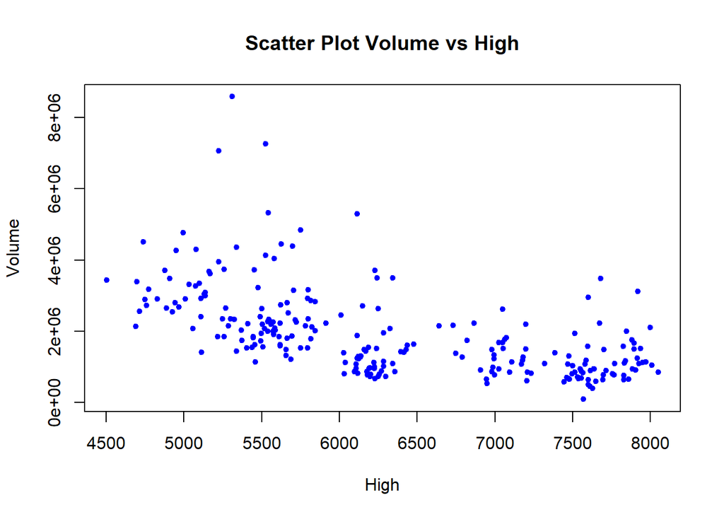

```r
# scatter plot volume vs high
plot(datagab2$high, datagab2$volume, pch = 20, col = "blue",
     main = "Scatter Plot Volume vs High",
     xlab = "High",
     ylab = "Volume")
```

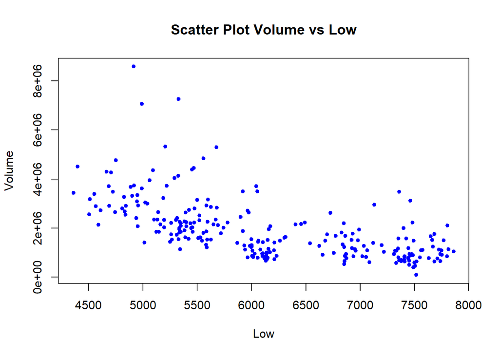

```r
# scatter plot Volume vs low
plot(datagab2$low,datagab$volume, pch = 20, col = "blue",
     main = "Scatter Plot Volume vs Low",
     xlab = "Low",
     ylab = "Volume")
```

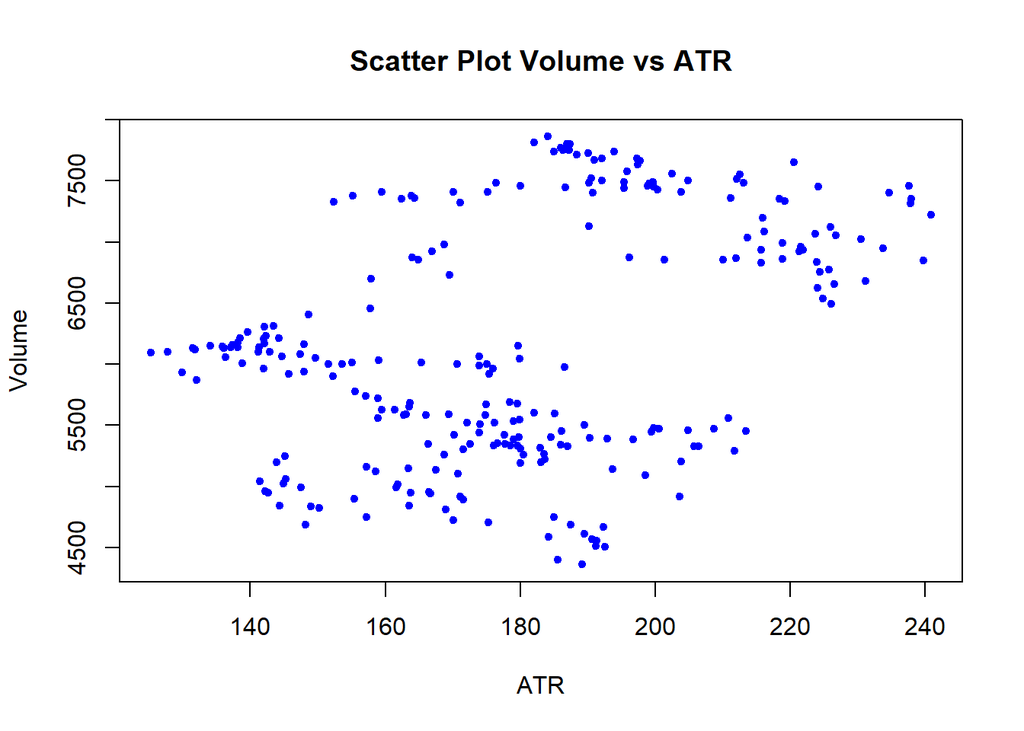

```r
# scatter plot Volume vs ATR
plot(datagab2$atr,datagab2$low, pch = 20, col = "blue",
     main = "Scatter Plot Volume vs ATR",
     xlab = "ATR",
     ylab = "Volume")
```

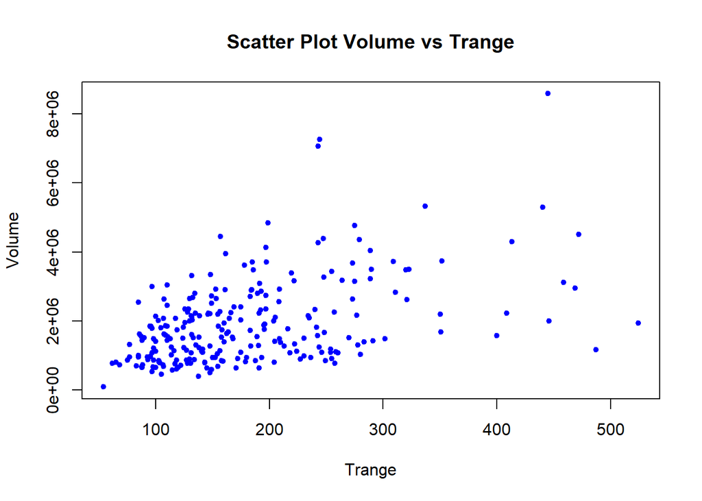

```r
# scatter plot Volume vs Trange
plot(datagab2$trange,datagab2$volume, pch = 20, col = "blue",
     main = "Scatter Plot Volume vs Trange",
     xlab = "Trange",
     ylab = "Volume")
```

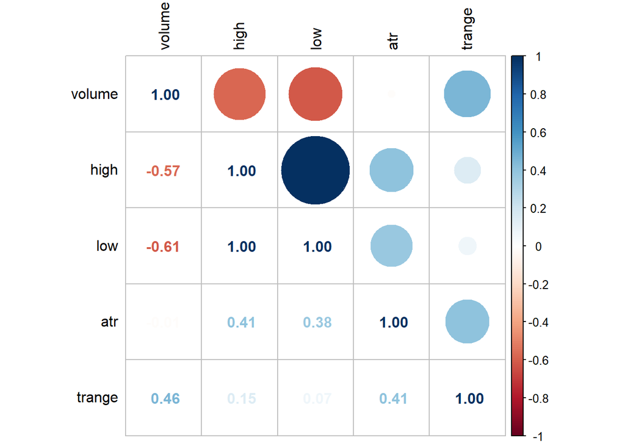

```r
# Cek Korelasi
matriks <- cor(datagab2)
corrplot.mixed(matriks, upper = 'circle', lower = 'number', order = "original",
               tl.col="black", tl.pos = "lt",diag = 'l',
               number.digits=2, number.cex=1)
```

# Plot time series

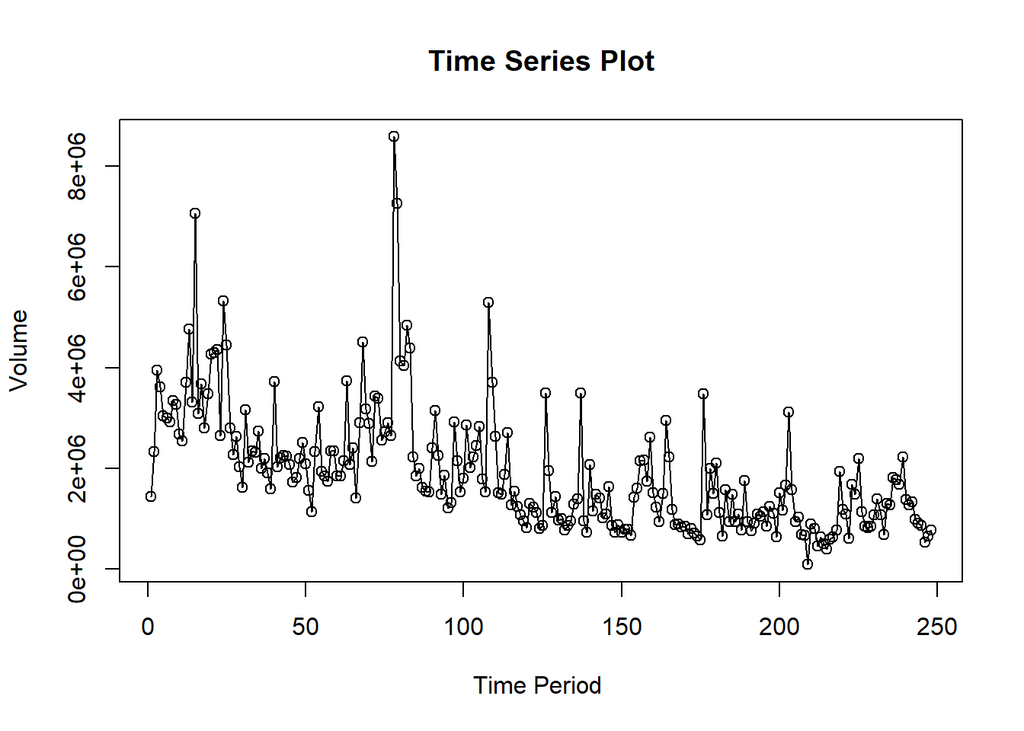

```r
## Volume
ts.plot(volume.ts, xlab="Time Period ", ylab="Volume",
        main = "Time Series Plot")
points(volume.ts)
```

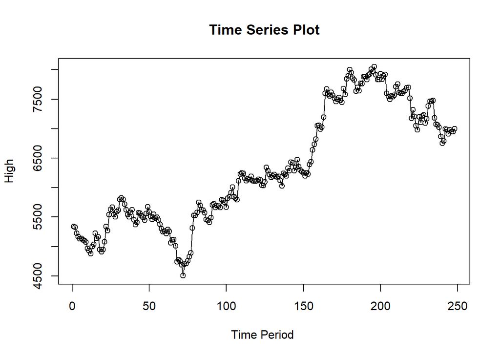

```r
## High
ts.plot(high.ts, xlab="Time Period ", ylab="High",
        main = "Time Series Plot")
points(high.ts)
```

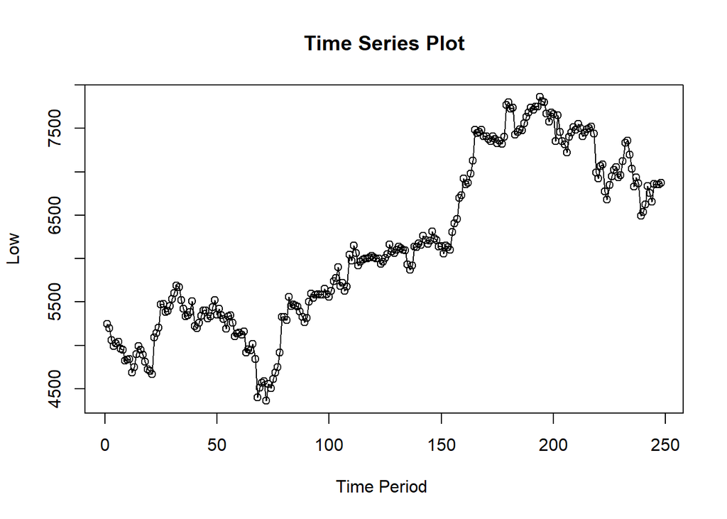

```r
## Low
ts.plot(low.ts, xlab="Time Period ", ylab="Low",
        main = "Time Series Plot")
points(low.ts)
```

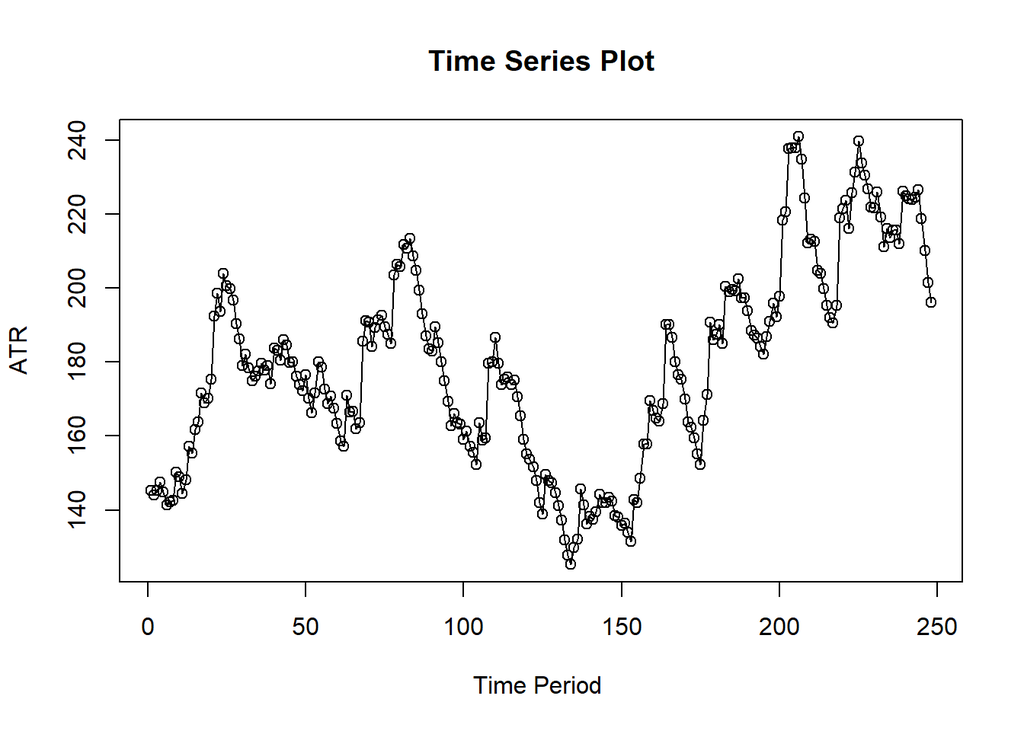

```r
## ATR
ts.plot(atr.ts, xlab="Time Period ", ylab="ATR",
        main = "Time Series Plot")
points(atr.ts)
```

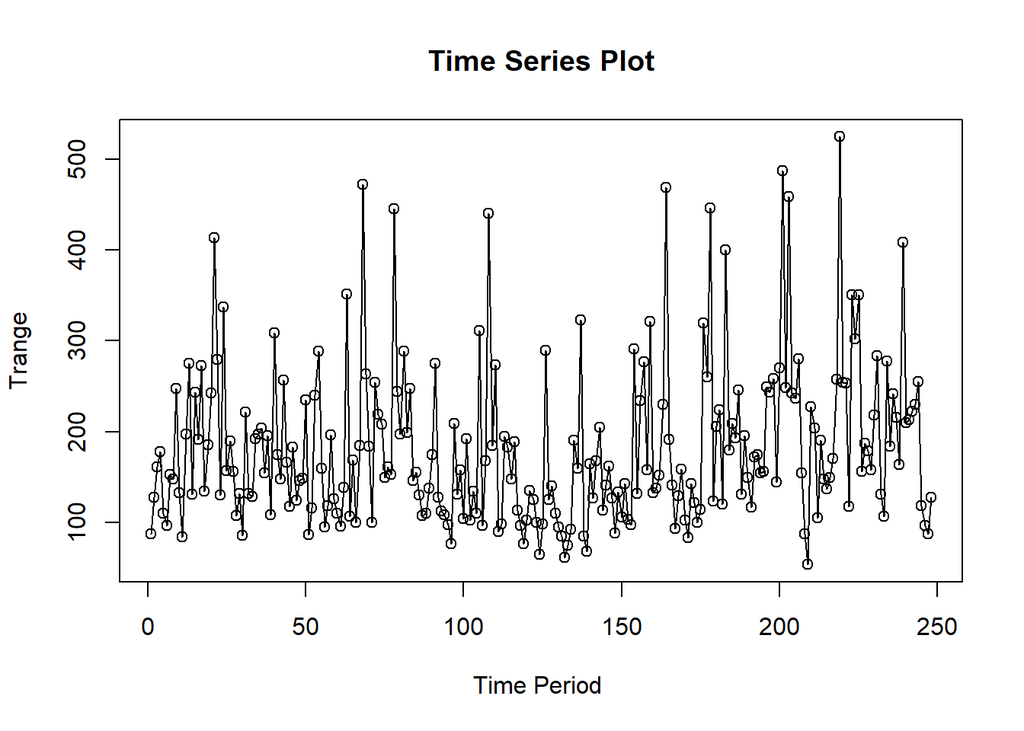

```r
## Trange
ts.plot(trange.ts, xlab="Time Period ", ylab="Trange",
        main = "Time Series Plot")
points(trange.ts)
```

# Pembuatan regresi time series

```r
## Pembuatan model awal
model1 <- lm(datagab2$volume ~ datagab2$high + datagab2$low + datagab2$atr + datagab2$trange)
summary(model1)
```

```
##
## Call:
## lm(formula = datagab2$volume ~ datagab2$high + datagab2$low +
##     datagab2$atr + datagab2$trange)
##
## Residuals:
##      Min       1Q   Median       3Q      Max
## -1871910  -454661  -129756   313690  4136303
##
## Coefficients:
##                  Estimate Std. Error t value Pr(>|t|)
## (Intercept)     5462897.1   372094.8  14.681  < 2e-16 ***
## datagab2$high     -1533.1     2552.3  -0.601 0.548631
## datagab2$low        711.8     2563.6   0.278 0.781523
## datagab2$atr       1547.3     2070.4   0.747 0.455575
## datagab2$trange    8260.3     2454.1   3.366 0.000887 ***
## ---
## Signif. codes:  0 '***' 0.001 '**' 0.01 '*' 0.05 '.' 0.1 ' ' 1
##
## Residual standard error: 744200 on 243 degrees of freedom
## Multiple R-squared:  0.6316, Adjusted R-squared:  0.6255
## F-statistic: 104.1 on 4 and 243 DF,  p-value: < 2.2e-16
```

Model yang dihasilkan adalah
$$y_i=5462897.1-1533.11_t+711.8x2_t+1547.3x3_t+8260x4_t$$

Berdasarkan ringkasan model dapat diketahui bahwa hasil uji F memiliki
$$p-value <\alpha$$
alpha 5% Artinya, dalam taraf 5% minimal terdapat satu peubah bebas yang berpengaruh nyata terhadap model.

Hasil uji-t parsial parameter regresi, yaitu koefisien regresi data trange menunjukkan hal yang sama, yaitu memiliki
$$t-value < \alpha$$
alpha 5%. Artinya, dalam taraf nyata 5% peubah Trange memiliki pengaruh yang signifikan terhadap model.

Selanjutnya dapat dilihat juga nilai
$$R^2=0.6255$$
Artinya, sebesar 62% keragaman nilai volume dapat dijelaskan oleh peubah-peubah tersebut. Namun, kita perlu melakukan uji terhadap sisaannya seperti berikut ini.

# plot asumsi

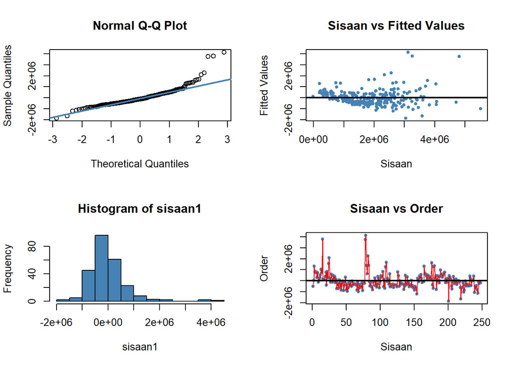

```r
#sisaan dan fitted value
sisaan1<- residuals(model1)
fitValue1<- predict(model1)

#Diagnostik dengan eksploratif
par(mfrow = c(2,2))
qqnorm(sisaan1)
qqline(sisaan1, col = "steelblue", lwd = 2)
plot(fitValue1, sisaan1, col = "steelblue", pch = 20, xlab = "Sisaan", ylab = "Fitted Values", main = "Sisaan vs Fitted Values")
abline(a = 0, b = 0, lwd = 2)
hist(sisaan1, col = "steelblue")
plot(seq(1,248,1), sisaan1, col = "steelblue", pch = 20, xlab = "Sisaan", ylab = "Order", main = "Sisaan vs Order")
lines(seq(1,248,1), sisaan1, col = "red")
abline(a = 0, b = 0, lwd = 2)
```

Dua plot di samping kiri digunakan untuk melihat apakah sisaan menyebar normal. Normal Q-Q Plot di atas menunjukkan bahwa sisaan cenderung tidak menyebar normal, dan histogram dari sisaan menunjukkan demikian. Selanjutnya, dua plot di samping kanan digunakan untuk melihat autokorelasi. Plot Sisaan vs *Fitted Value* dan Plot Sisaan vs *Order* menunjukkan adanya pola pada sisaan. Untuk lebih lanjut akan digunakan uji formal melihat normalitas sisaan dan plot ACF dan PACF untuk melihat apakah ada autokorelasi atau tidak.

# Uji formal Normalitas

```r
#H0: sisaan menyebar normal
#H1: sisaan tidak menyebar normal
ks.test(sisaan1, "pnorm", mean=mean(sisaan1), sd=sd(sisaan1))
```

```
##
##  Asymptotic one-sample Kolmogorov-Smirnov test
##
## data:  sisaan1
## D = 0.10018, p-value = 0.01378
## alternative hypothesis: two-sided
```

Berdasarkan uji formal Kolmogorov-Smirnov didapatkan nilai
$$p-value<\alpha$$
(5%). Tolak H0. Artinya, belum cukup bukti untuk menyatakan sisaan berdistribusi normal.

# Transformasi karna data tidak normal (1/x dan 1/y)

```r
volume.trans <- 1/(datagab2$volume)
high.trans <- 1/(datagab2$high)
low.trans <- 1/(datagab2$low)
atr.trans <- 1/(datagab2$atr)
trange.trans <- 1/(datagab2$trange)
# Model transformasi
model2 <- lm(volume.trans ~ high.trans +low.trans + atr.trans + trange.trans)
summary(model2)
```

```
##
## Call:
## lm(formula = volume.trans ~ high.trans + low.trans + atr.trans +
##     trange.trans)
##
## Residuals:
##        Min         1Q     Median         3Q        Max
## -9.586e-07 -2.424e-07  1.100e-08  2.015e-07  6.935e-06
##
## Coefficients:
##                Estimate Std. Error t value Pr(>|t|)
## (Intercept)   2.579e-06  2.849e-07   9.050  < 2e-16 ***
## high.trans   -1.363e-01  2.813e-02  -4.844 2.27e-06 ***
## low.trans     1.177e-01  2.659e-02   4.428 1.44e-05 ***
## atr.trans    -1.548e-04  4.726e-05  -3.276  0.00121 **
## trange.trans  2.261e-04  2.253e-05  10.035  < 2e-16 ***
## ---
## Signif. codes:  0 '***' 0.001 '**' 0.01 '*' 0.05 '.' 0.1 ' ' 1
##
## Residual standard error: 5.575e-07 on 243 degrees of freedom
## Multiple R-squared:  0.4615, Adjusted R-squared:  0.4526
## F-statistic: 52.06 on 4 and 243 DF,  p-value: < 2.2e-16
```

Model transforasi yang dihasilkan adalah
$$y_i=(2.579e-06)-(1.363e-01)x1_t+(1.177e-01)x2_t-(1.548e-04)x3_t+(2.261e-04)x4_t$$

Berdasarkan ringkasan model dapat diketahui bahwa hasil uji F memiliki
$$p-value < \alpha$$
(5%). Artinya, dalam taraf nyata 5% minimal terdapat satu peubah bebas yang berpengaruh nyata terhadap model.

Hasil uji-t parsial parameter regresi, yaitu koefisien regresi juga menunjukkan hal yang sama, yaitu memiliki
$$t-value < \alpha$$
(5%) Artinya, dalam taraf nyata 5% peubah bebas berpengaruh nyata terhadap model.

Selanjutnya dapat dilihat juga nilai
$$R^2=0.4526$$
. Artinya, sebesar 45% keragaman nilai volume dapat dijelaskan oleh peubah high, low, atr, dan trange. Namun, kita perlu melakukan uji terhadap sisaannya seperti berikut ini.

# cek ulang normalitas

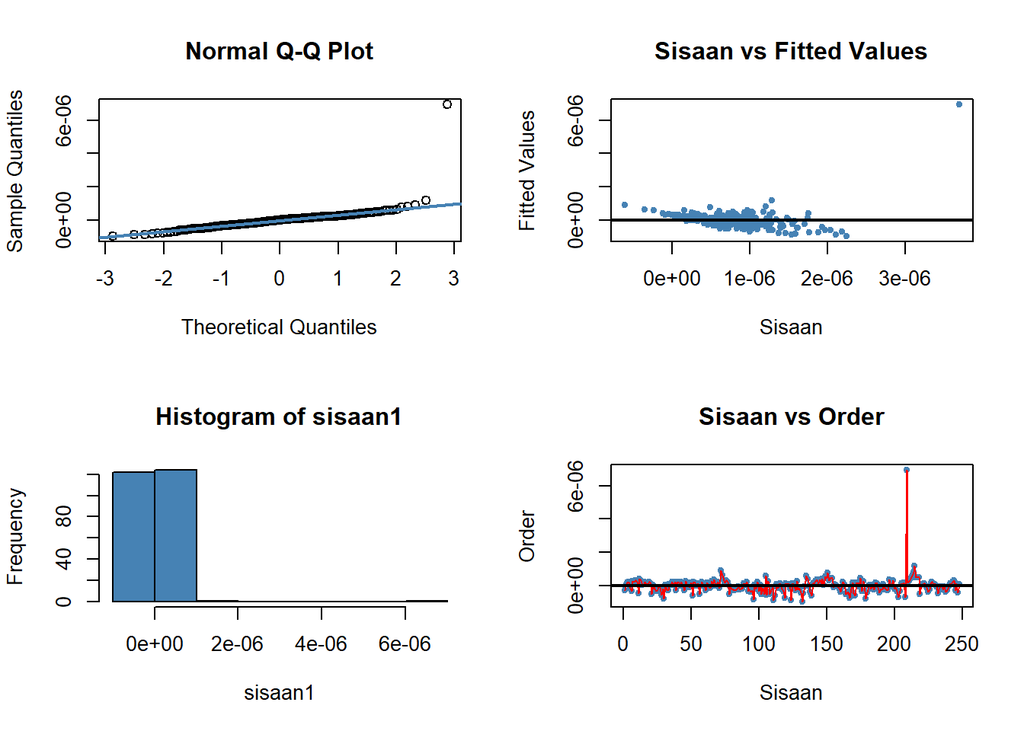

```r
#sisaan dan fitted value
sisaan1<- residuals(model2)
fitValue1<- predict(model2)

#Diagnostik dengan eksploratif
par(mfrow = c(2,2))
qqnorm(sisaan1)
qqline(sisaan1, col = "steelblue", lwd = 2)
plot(fitValue1, sisaan1, col = "steelblue", pch = 20, xlab = "Sisaan", ylab = "Fitted Values", main = "Sisaan vs Fitted Values")
abline(a = 0, b = 0, lwd = 2)
hist(sisaan1, col = "steelblue")
plot(seq(1,248,1), sisaan1, col = "steelblue", pch = 20, xlab = "Sisaan", ylab = "Order", main = "Sisaan vs Order")
lines(seq(1,248,1), sisaan1, col = "red")
abline(a = 0, b = 0, lwd = 2)
```

# Uji Formal normalitas

```r
#H0: sisaan mengikuti sebaran normal
#H1: sisaan tidak mengikuti sebaran normal
ks.test(sisaan1, "pnorm", mean=mean(sisaan1), sd=sd(sisaan1))
```

```
##
##  Asymptotic one-sample Kolmogorov-Smirnov test
##
## data:  sisaan1
## D = 0.181, p-value = 1.755e-07
## alternative hypothesis: two-sided
```

# ACF dan PACF identifikasi autokorelasi

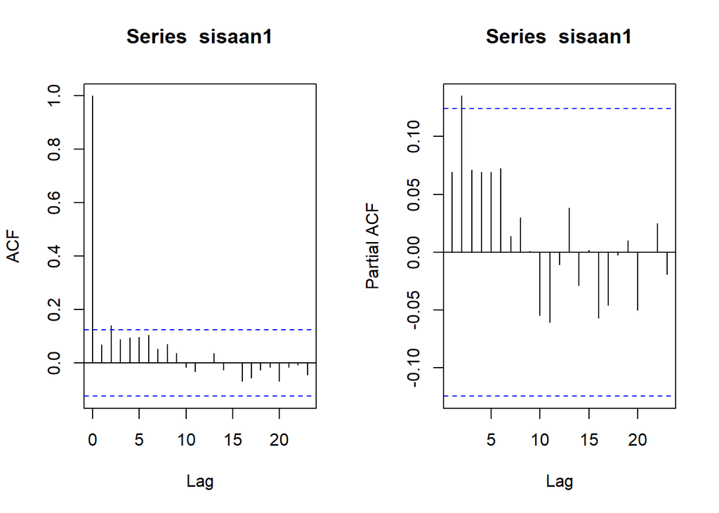

```r
par(mfrow = c(1,2))
acf(sisaan1)
pacf(sisaan1)
```

Berdasarkan plot ACF dan PACF, terlihat terdapat data yang berada diluar rentang batas sehingga terdapat autokorelasi. Namun, untuk lebih memastikan akan dilakukan uji formal dengan uji Durbin Watson.

# Uji formal autokorelasi

```r
#H0: tidak ada autokorelasi
#H1: ada autokorelasi
dwtest(model2)
```

```
##
##  Durbin-Watson test
##
## data:  model2
## DW = 1.8607, p-value = 0.1054
## alternative hypothesis: true autocorrelation is greater than 0
```

# Penanganan Autokorelasi

#Penanganan Autokorelasi Metode Cochrane-Orcutt

```r
#H0:Terdapat autokorelasi
#H2:Tidak terdapat autokorelasi
model.CO <- cochrane.orcutt(model2)
model.CO
```

```
## Cochrane-orcutt estimation for first order autocorrelation
##
## Call:
## lm(formula = volume.trans ~ high.trans + low.trans + atr.trans +
##     trange.trans)
##
##  number of interaction: 3
##  rho 0.069141
##
## Durbin-Watson statistic
## (original):    1.86068 , p-value: 1.054e-01
## (transformed): 2.01755 , p-value: 4.988e-01
##
##  coefficients:
##  (Intercept)   high.trans    low.trans    atr.trans trange.trans
##     0.000003    -0.135893     0.117431    -0.000153     0.000226
```

```r
model.CO$coefficients
```

```
##   (Intercept)    high.trans     low.trans     atr.trans  trange.trans
##  2.559533e-06 -1.358928e-01  1.174308e-01 -1.527687e-04  2.259797e-04
```

Hasil keluaran model setelah dilakukan penanganan adalah sebagai berikut.
$$y_i=0.000003-0.135893x1_t+0.117431x2_t-0.000153x3_t+0.000226x4_t$$
Hasil juga menunjukkan bahwa nilai DW dan p-value meningkat menjadi $2.01755$ dan $4.988e-01$. Dengan nilai
$$p-value > 0.05$$
Tolak H0. Artinya, pada taraf nyata 5% belum cukup bukti menyatakan bahwa sisaan terdapat autokorelasi.

Untuk nilai $ρ ̂$ optimum yang digunakan adalah $0.06914128$. Nilai tersebut dapat diketahui dengan *syntax* berikut.

```r
#Rho optimum
rho1<- model.CO$rho
rho1
```

```
## [1] 0.06914128
```

## Transformasi manual

```r
#Transformasi Manual
volume.trans2<- volume.trans[-1]-volume.trans[-248]*rho1
high.trans2<- high.trans[-1]-high.trans[-248]*rho1
low.trans2<- low.trans[-1]-low.trans[-248]*rho1
atr.trans2<- atr.trans[-1]-atr.trans[-248]*rho1
trange.trans2<- trange.trans[-1]-trange.trans[-248]*rho1
model.CO.manual<- lm(volume.trans2 ~ high.trans2 + low.trans2 + atr.trans2 + trange.trans2)
summary(model.CO.manual)
```

```
##
## Call:
## lm(formula = volume.trans2 ~ high.trans2 + low.trans2 + atr.trans2 +
##     trange.trans2)
##
## Residuals:
##        Min         1Q     Median         3Q        Max
## -9.359e-07 -2.366e-07 -4.000e-09  1.990e-07  6.986e-06
##
## Coefficients:
##                 Estimate Std. Error t value Pr(>|t|)
## (Intercept)    2.383e-06  2.854e-07   8.348 5.38e-15 ***
## high.trans2   -1.359e-01  2.821e-02  -4.818 2.57e-06 ***
## low.trans2     1.174e-01  2.666e-02   4.405 1.59e-05 ***
## atr.trans2    -1.528e-04  5.036e-05  -3.033  0.00268 **
## trange.trans2  2.260e-04  2.275e-05   9.931  < 2e-16 ***
## ---
## Signif. codes:  0 '***' 0.001 '**' 0.01 '*' 0.05 '.' 0.1 ' ' 1
##
## Residual standard error: 5.57e-07 on 242 degrees of freedom
## Multiple R-squared:  0.4447, Adjusted R-squared:  0.4355
## F-statistic: 48.44 on 4 and 242 DF,  p-value: < 2.2e-16
```

```r
#Mencari Penduga Koefisien Regresi setelah Transformasi ke Persamaan Awal
b0bintang <- model.CO.manual$coefficients[1]
b0<- b0bintang/(1-rho1)
b0
```

```
##  (Intercept)
## 2.559533e-06
```

```r
b1<- model.CO.manual$coefficients[2]
b1
```

```
## high.trans2
##  -0.1358928
```

```r
b2<- model.CO.manual$coefficients[3]
b2
```

```
## low.trans2
##  0.1174308
```

```r
b3<- model.CO.manual$coefficients[4]
b3
```

```
##    atr.trans2
## -0.0001527687
```

```r
b4<- model.CO.manual$coefficients[5]
b4
```

```
## trange.trans2
##  0.0002259797
```

#Penanganan Autokorelasi Metode Hildreth-Lu

```r
hildreth.lu.func<- function(r, model){
  x1 <- model.matrix(model)[,2]
  x2 <- model.matrix(model)[,3]
  x3 <- model.matrix(model)[,4]
  x4 <- model.matrix(model)[,5]
  y <- model.response(model.frame(model))
  n <- length(y)
  t <- 2:n
  y <- y[t]-r*y[t-1]
  x1 <- x1[t]-r*x1[t-1]
  x2 <- x2[t]-r*x2[t-1]
  x3 <- x3[t]-r*x3[t-1]
  x4 <- x4[t]-r*x4[t-1]

  return(lm(y~x1+x2+x3+x4))
}
```

```r
#Pencariab rho yang meminimumkan SSE
r <- c(seq(0.1,0.9, by= 0.1))
tab <- data.frame("rho" = r, "SSE" = sapply(r, function(i){deviance(hildreth.lu.func(i, model2))}))
tab
```

| rho | SSE |
| --- | --- |
| 0.1 | 7.515188e-11 |
| 0.2 | 7.637067e-11 |
| 0.3 | 7.909591e-11 |
| 0.4 | 8.332594e-11 |
| 0.5 | 8.905718e-11 |
| 0.6 | 9.628081e-11 |
| 0.7 | 1.049729e-10 |
| 0.8 | 1.150615e-10 |
| 0.9 | 1.263430e-10 |

Pertama-tama akan dicari di mana kira-kira $ρ$ yang menghasilkan SSE minimum. Pada hasil di atas terlihat $ρ$ minimum ketika 0.1. Namun, hasil tersebut masih kurang teliti sehingga akan dicari kembali $ρ$ yang lebih optimum dengan ketelitian yang lebih. Jika sebelumnya jarak antar $ρ$ yang dicari adalah 0.1, kali ini jarak antar $ρ$ adalah 0.001 dan dilakukan pada selang 0.1 sampai dengan 0.4.

```r
r.opt<- seq(0.1,0.4, by= 0.001)
tab.opt <- data.frame("rho" = r.opt, "SSE" = sapply(r.opt, function(i){deviance(hildreth.lu.func(i, model2))}))
tab.opt[order(tab.opt$SSE),]
```

|  | rho | SSE |
| --- | --- | --- |
| 1 | 0.100 | 7.515188e-11 |
| 2 | 0.101 | 7.515661e-11 |
| 3 | 0.102 | 7.516148e-11 |
| 4 | 0.103 | 7.516651e-11 |
| 5 | 0.104 | 7.517169e-11 |
| 6 | 0.105 | 7.517702e-11 |
| 7 | 0.106 | 7.518250e-11 |
| 8 | 0.107 | 7.518814e-11 |
| 9 | 0.108 | 7.519392e-11 |
| 10 | 0.109 | 7.519985e-11 |

[output cut: 291 more lines]

```r
tab.opt[tab.opt$SSE == min(tab.opt$SSE),]
```

|  | rho | SSE |
| --- | --- | --- |
| 1 | 0.1 | 7.515188e-11 |

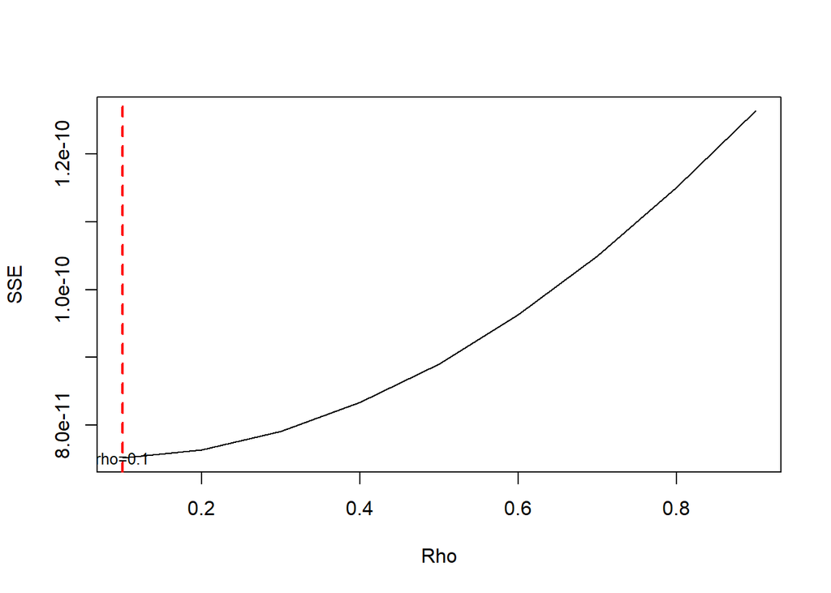

```r
#Grafik SSE optimum
par(mfrow = c(1,1))
plot(tab$SSE ~ tab$rho , type = "l", xlab = "Rho", ylab = "SSE")
abline(v = tab.opt[tab.opt$SSE==min(tab.opt$SSE),"rho"], lty = 2, col="red",lwd=2)
text(x=0.1, y=7.515188e-11      , labels = "rho=0.1", cex = 0.8)
```

Perhitungan yang dilakukan aplikasi `R` menunjukkan bahwa nilai $ρ$ optimum, yaitu saat SSE terkecil terdapat pada nilai $ρ=0.100$. Hal tersebut juga ditunjukkan pada plot. Selanjutnya, model dapat didapatkan dengan mengevaluasi nilai $ρ$ ke dalam fungsi `hildreth.lu.func`, serta dilanjutkan dengan pengujian autokorelasi dengan uji Durbin-Watson. Namun, setelah pengecekan tersebut tidak lupa koefisien regresi tersebut digunakan untuk transformasi balik. Persamaan hasil transformasi itulah yang menjadi persamaan sesungguhnya.

```r
#Model terbaik
model.HL <- hildreth.lu.func(0.100, model2)
summary(model.HL)
```

```
##
## Call:
## lm(formula = y ~ x1 + x2 + x3 + x4)
##
## Residuals:
##        Min         1Q     Median         3Q        Max
## -9.222e-07 -2.260e-07 -1.800e-09  1.968e-07  7.012e-06
##
## Coefficients:
##               Estimate Std. Error t value Pr(>|t|)
## (Intercept)  2.300e-06  2.854e-07   8.059 3.52e-14 ***
## x1          -1.357e-01  2.823e-02  -4.808 2.68e-06 ***
## x2           1.173e-01  2.667e-02   4.397 1.64e-05 ***
## x3          -1.521e-04  5.193e-05  -2.929  0.00373 **
## x4           2.256e-04  2.283e-05   9.885  < 2e-16 ***
## ---
## Signif. codes:  0 '***' 0.001 '**' 0.01 '*' 0.05 '.' 0.1 ' ' 1
##
## Residual standard error: 5.573e-07 on 242 degrees of freedom
## Multiple R-squared:  0.4365, Adjusted R-squared:  0.4272
## F-statistic: 46.87 on 4 and 242 DF,  p-value: < 2.2e-16
```

```r
#Transformasi Balik
cat("y = ", coef(model.HL)[1]/(1-0.100), coef(model.HL)[2],"x1","+", coef(model.HL)[3],"x2", coef(model.HL)[4],"x3", "+", coef(model.HL)[5], "x4",sep = "")
```

```
## y = 2.555798e-06-0.135709x1+0.1172652x2-0.0001520892x3+0.0002256425x4
```

Setelah dilakukan tranformasi balik, didapatkan model dengan metode Hildreth-Lu sebagai berikut.
$$y_i=(2.555798e-06)-(0.135709)x1_t+(0.1172652)x2_t-(0.0001520892)x3_t+(0.0002256425)x4_t$$

```r
#Deteksi autokorelasi
dwtest(model.HL)
```

```
##
##  Durbin-Watson test
##
## data:  model.HL
## DW = 2.0872, p-value = 0.7092
## alternative hypothesis: true autocorrelation is greater than 0
```

# Perbandingan keakuratan

```r
sseModelawal <- anova(model2)$`Sum Sq`[c(5)]
sseModelCO <- anova(model.CO.manual)$`Sum Sq`[c(5)]
sseModelHL <- anova(model.HL)$`Sum Sq`[c(5)]
mseModelawal <- sseModelawal/length(volume.trans)
mseModelCO <- sseModelCO/length(volume.trans)
mseModelHL <- sseModelHL/length(volume.trans)
akurasi <- matrix(c(sseModelawal,sseModelCO,sseModelHL,
                    mseModelawal,mseModelCO,mseModelHL),nrow=2,ncol=3,byrow = T)
colnames(akurasi) <- c("Model_Awal", "Model_Cochrane-Orcutt", "Model_Hildreth-Lu")
row.names(akurasi) <- c("SSE","MSE")
akurasi
```

```
##       Model_Awal Model_Cochrane-Orcutt Model_Hildreth-Lu
## SSE 7.552567e-11          7.508010e-11      7.515188e-11
## MSE 3.045390e-13          3.027423e-13      3.030318e-13
```

# Simpulan